# Combining Vector and Raster Datasets

Syed Faraz Ali

10/09/2018

# Creating rasters from vector layers

Generating new insight by overlaying several layers of spatial information, one on top of the other, constitutes one of the main concepts of spatial data analysis. Combining them in a single analysis is often desired.

In this tutorial, we’ll cover the following topics:

- Creating rasters from vector layers and vice versa
- Masking rasters with vector layers
- Extracting raster values according to vector layers

# Creating rasters from vector layers

To do this, we use the rasterize function

## Rasterizing vector layers

- Given a vector layer and a raster grid, the new raster cells get filled with values in places where the raster overlaps with the vector layer.
- The rest of the raster cells (those that are not in contact with the vector layer) are left with NA.
- Those raster cells that overlap with an individual feature in the vector layer are assigned unique values.

This will get clear from the following example:

Reading the helper files first

```r
source("~/codes/credit_risk_product/utils.R")
source("~/codes/credit_risk_product/settings.R")
import_libraries()
```

```
## [1] "Importing Libraries...."
## [1] "Libraries imported!"
```

# Reading rasters layer

```r
rast1 <- raster("~/data/2017/NDVI/ndvi_20171015_agmask_clipped.tif")
print(rast1)
```

```
## class       : RasterLayer
## dimensions  : 12297, 14610, 179659170  (nrow, ncol, ncell)
## resolution  : 10, 10  (x, y)
## extent      : 754185.4, 900285.4, 2000566, 2123536  (xmin, xmax, ymin, ymax)
## coord. ref. : +proj=utm +zone=44 +datum=WGS84 +units=m +no_defs +ellps=WGS84 +towgs84=0,0,0
## data source : /home/ubuntu/data/2017/NDVI/ndvi_20171015_agmask_clipped.tif
## names       : ndvi_20171015_agmask_clipped
## values      : 0, 255  (min, max)
```

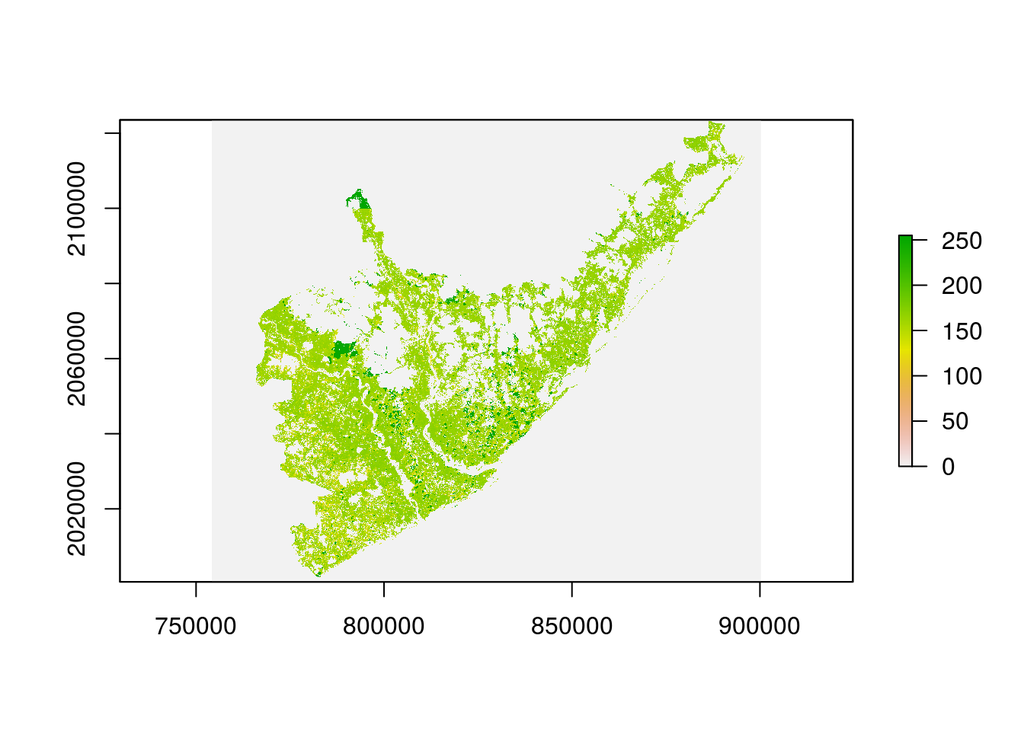

```r
plot(rast1)
```

# Reading the vector layer (mandal shapefile)

```r
amal <- readOGR("~/data/SHP/Amadalavalasa.geojson")
print(amal)
```

```
## class       : SpatialPolygonsDataFrame
## features    : 1
## extent      : 83.81686, 83.93874, 18.35315, 18.46378  (xmin, xmax, ymin, ymax)
## coord. ref. : +proj=longlat +datum=WGS84 +no_defs +ellps=WGS84 +towgs84=0,0,0
## variables   : 12
## names       : Country, CountryCode, State., StateCode.,  District., DistrictCode,        Mandal, MandalCode., Village, VillageCode,       RegionID, UpadateDate
## value       :   India,          91,     AP,          2, Srikakulam,           10, Amadalavalasa,           1,      NA,           0, 91002010001000,    20180612
```

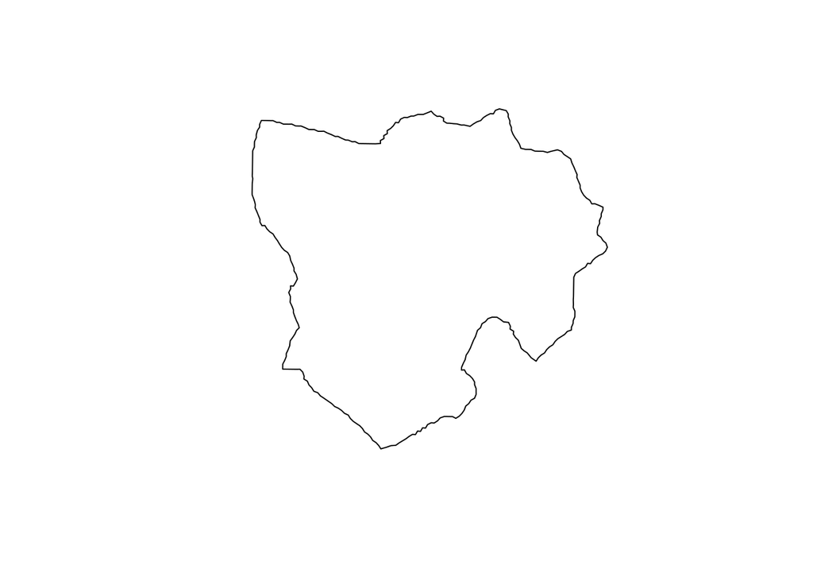

```r
plot(amal)
```

# Reprojecting the vector layer to same CRS as the raster layer

```r
amal <- spTransform(amal, CRS(proj4string(rast1)))
```

# Plotting the raster and vector layers on the same plot

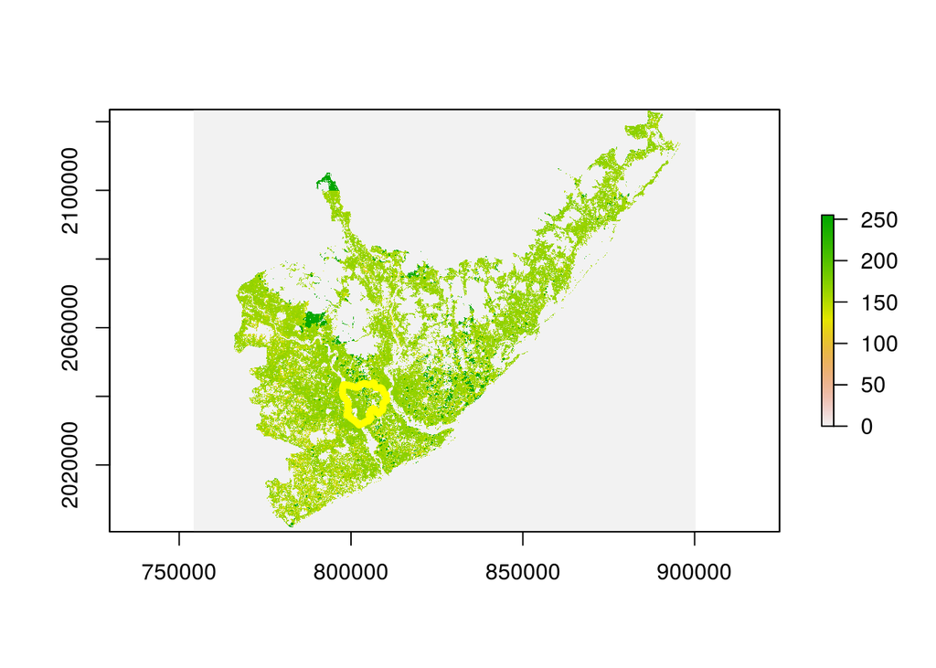

```r
plot(rast1)
plot(amal, border = "yellow", lwd = 5, add = TRUE)
```

Now it is better if we first crop the raster as per the mandal extent and then plot them

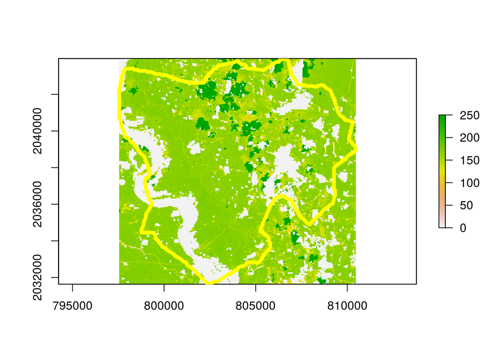

```r
rast1 <- crop(rast1, amal)
plot(rast1)
plot(amal, border = "yellow", lwd = 5, add = TRUE)
```

## Rasterizing the vector layer

Since we have one polygon layer, our result is going to be a raster with the raster cells inside the polygon layer having a non-NA value and outside the polygon layer, it’ll be NA

The rasterize() function requires two main arguments:

- The vector layer to rasterize(x)
- The raster defining the grid(y)

Note that the role of y is ONLY to provide a raster grid definition; its values DO NOT participate in the operation in any way.

Now, rasterizing

```r
amal_r <- rasterize(amal, rast1)
print(amal_r)
```

```
## factor levels (value attributes)
##   ID Country CountryCode State. StateCode.  District. DistrictCode
## 0  1   India          91     AP          2 Srikakulam           10
##          Mandal MandalCode. Village VillageCode       RegionID UpadateDate
## 0 Amadalavalasa           1      NA           0 91002010001000    20180612
```

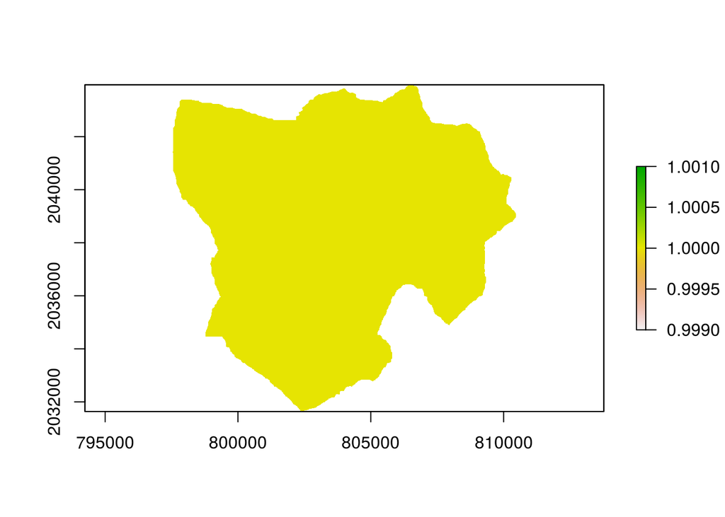

```r
plot(amal_r)
```

Now if we compare raster rast1 and the rasterized vector amal_r, we can see that they have the same number of rows and columns( hence the number of cells as well), also their extents are also same

```r
print(amal_r)
```

```
## factor levels (value attributes)
##   ID Country CountryCode State. StateCode.  District. DistrictCode
## 0  1   India          91     AP          2 Srikakulam           10
##          Mandal MandalCode. Village VillageCode       RegionID UpadateDate
## 0 Amadalavalasa           1      NA           0 91002010001000    20180612
```

```r
print(rast1)
```

```
## class       : RasterLayer
## dimensions  : 1232, 1292, 1591744  (nrow, ncol, ncell)
## resolution  : 10, 10  (x, y)
## extent      : 797545.4, 810465.4, 2031636, 2043956  (xmin, xmax, ymin, ymax)
## coord. ref. : +proj=utm +zone=44 +datum=WGS84 +units=m +no_defs +ellps=WGS84 +towgs84=0,0,0
## data source : in memory
## names       : ndvi_20171015_agmask_clipped
## values      : 0, 250  (min, max)
```

# Masking values in a raster

An important point to note before we start this discussion: Rasters are always rectangular. However in raster subsetting, we are often interested in going beyond the selection of ractangular extents

Non-rectangular rasters can be created by assigning all cells, excluding those we are interested in, with NA.

This operation is called masking, again in the raster package terminology.

Masking is most often performed using a polygonal layer defning an area of interest. Therefore, conceptually, masking can be viewed as a two-step operation.

- The first step consists of a vector-to-raster conversion, where the area of interest is rasterized according to the raster we would like to mask.
- The second step consists of an overlay to construct the masked raster, with NA in those cells where the area-of-interest raster has NA or the original value otherwise.

In practice, the operation may be performed with a single step, using the mask function.

This will be made clear with the following example:

We want to find the raster corresponding to the amal shapefile (NOT the amal extent). We will mask the raster rast1 with the polygonal layer of mandal Amadalavasala.

We already have the cropped raster(as per the mandal shapefile extent)

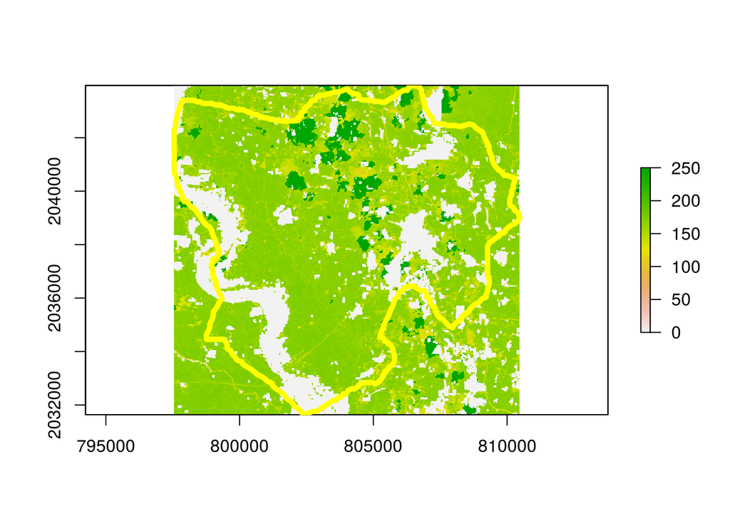

```r
plot(rast1)
plot(amal, border = "yellow", lwd = 5, add = TRUE)
```

The mask function that we will use expects two main arguments:

- The raster to be masked (x)
- The object determining which values to mask(mask)

### IMPORTANT : The mask argument can either be an overlapping raster (in which case the values in x corresponding to NA in mask are assigned with NA) or a vector layer (in which case the values in x not coinciding with any features in mask are assigned with NA)

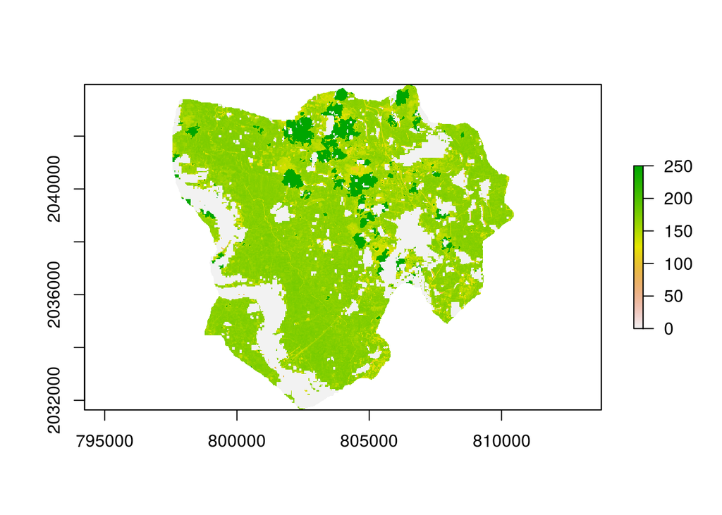

```r
rast1_mask <- mask(rast1, amal)
plot(rast1_mask)
```

### We can also mask the raster rast1_mask with another raster (maize_raster) to further filter the values corresponding to the maize pixels.

### But first we will have to resample the maize raster as per rast1_masked